# Troubleshooting

The following sections describe how to troubleshoot the Chef Infra Server, Chef Infra Client, and Chef Workstation.

## 401 Unauthorized

There are multiple causes of the Chef 401 “Unauthorized” error, so please use the sections below to find the error message that most closely matches your output. If you are unable to find a matching error, or if the provided steps are unhelpful, please [file a help ticket](https://getchef.zendesk.com/hc/en-us).

### Failed to authenticate as ORGANIZATION-validator

If you’re receiving an error like the following it most likely means you’ll need to regenerate the ORGANIZATION-validator.pem file:

```bash
INFO: Client key /etc/chef/client.pem is not present - registering
INFO: HTTP Request Returned 401 Unauthorized: Failed to authenticate as ORGANIZATION-validator. Ensure that your node_name and client key are correct.
FATAL: Stacktrace dumped to c:/chef/cache/chef-stacktrace.out
FATAL: Net::HTTPClientException: 401 "Unauthorized"
```

#### Troubleshooting Steps

1. Check if the ORGANIZATION-validator.pem file exists in one of the following locations:

   ```
   ~/.chef
   ~/projects/current_project/.chef
   /etc/chef
   ```

   If one is present, verify that it has the correct read permissions.
2. If there’s no ORGANIZATION-validator.pem file, regenerate it.

   Recreate this file by going to the Chef management console web user interface and selecting **Organizations** in the upper right side of the screen.

   You can then select **Reset Validation Key** next to the organization for which the key is to be reset.

## Failed to authenticate to

When the values for certain settings in the client.rb file—`node_name` and `client_key`—are incorrect, it will not be possible to authenticate to the Chef Infra Server. An error similar to the following is shown:

```bash
ERROR: Failed to authenticate to https://api.opscode.com/organizations/ORGANIZATION as USERNAME with key /path/to/USERNAME.pem
Response:  Failed to authenticate as USERNAME. Ensure that your node_name and client key are correct.
```

### Troubleshooting Steps

- Verify you have the correct values in your config.rb file, especially for the `node_name` and `client_key` settings.
- Check if the file referenced in the `client_key` setting (usually USER.pem) exists. Some common locations include:
  - `~/.chef`
  - `~/projects/current_project/.chef`
  - `/etc/chef`

    If one is present, verify that it has the correct read permissions.
- If there’s no client.rb file, regenerate it and ensure the values for the `node_name` and `client_key` settings are correct.

### Organization not found

If you see this error when trying to recreate the ORGANIZATION-validator.pem, it’s possible that Chef Infra Client itself was deleted. In this situation, the ORGANIZATION-validator.pem will need to be recreated. In these directions, `ORGANIZATION` should be replaced with the name of your organization.

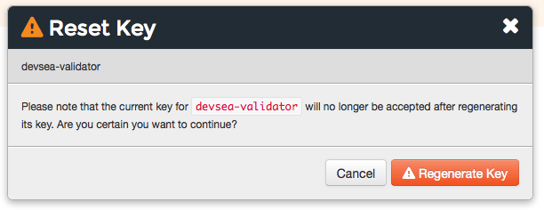

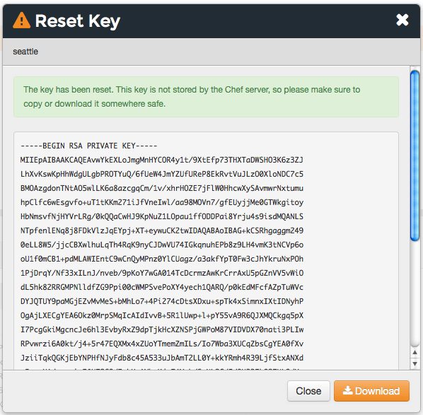

   or download and save the private key locally:

[figure not shown]

### Synchronize the clock on your host

If the system clock drifts more than 15 minutes from the actual time, the following type of error will be shown:

```bash
INFO: Client key /etc/chef/client.pem is not present - registering
INFO: HTTP Request Returned 401 Unauthorized: Failed to authenticate as ORGANIZATION-validator. Synchronize the clock on your host.
FATAL: Stacktrace dumped to /var/chef/cache/chef-stacktrace.out
FATAL: Net::HTTPClientException: 401 "Unauthorized"
```

To resolve this error, synchronize the clock with an NTP server.

### All other 401 errors

The general `Net::HTTPClientException: 401 "Unauthorized"` error will usually occur for one of two reasons.

#### Troubleshooting Steps

1. Make sure your `client.pem` is valid.

   This can be fixed by deleting `client.pem` in `/etc/chef` and deleting the client and node with knife.

   On a management station:

   ```bash
   # Dump the current node to JSON
   knife node show NODE_NAME -fJ > NODE_NAME.json

   knife client delete FQDN -y
   knife node delete FQDN -y
   ```

   On an affected node (as root):

   ```bash
   rm /etc/chef/client.pem
   chef-client
   ```

   When Chef Infra Client runs, it will register the API client and generate the correct key.

   After successfully running Chef Infra Client on the node, reload the `run_list` and node attributes:

   ```bash
   knife node from file NODE_NAME.json
   ```

2. Make sure to use the same `node_name` as the initial Chef Infra Client run.

   This can happen for a number of reasons. For example, if the client.rb file does not specify the correct node name and the system’s hostname has changed.

   Running `chef-client -l debug` will identify the node name being used by Chef Infra Client for authentication attempts:

   ```bash
   DEBUG: Signing the request as SOME_NODE_NAME
   ```

   This can be fixed by explicitly setting `node_name` in the client.rb file to match the name originally used to register.

   ```ruby
   node_node 'mynode.mycompany.com'
   ```

   Alternatively, re-register the node using the method described previously.

## 403 Forbidden

If you’re seeing output like this:

```bash
FATAL: Stacktrace dumped to /var/chef/cache/chef-stacktrace.out
FATAL: Net::HTTPClientException: 403 "Forbidden"
```

this is an indication that there is an issue with permissions on the Chef Infra Server.

### Troubleshooting Steps

In Chef, there are two different types of permissions issues, object specific and global permissions. To figure out which type of permission issue you’re experiencing, run Chef Infra Client again using the `-l debug` options to see debugging output.

You should see something like this up the stack trace:

```bash
DEBUG: Sending HTTP Request to https://api.opscode.com/organizations/ORGNAME/nodes
ERROR: Running exception handlers
```

The URL will help identify the type of permission issue. If the URL is an index action (i.e. operating on a collection of resources, like `/nodes`) then this is a global permission. If the URL is operating on an instance of a collection (i.e. `/nodes/NODENAME`) then this is an object permission issue.

To fix the global permissions:

1. Log in to the Chef management console and click on the failing object type (most likely **Nodes**).
2. Click on the **Permissions** sub-tab. Which permission it needs, depends on which request that failed:

   GET - Under the group section, make sure it has the LIST permission checked POST - Under the group section, make sure it has the CREATE permission checked
3. Check the checkboxes needed and save the updates.

To fix object permissions:

1. Log in to the Chef management console and click on the failing object type (most likely **Nodes**).
2. Click on the object in the list that is causing the error.
3. Click on the **Permissions** sub-tab. Which permission it needs, depends on the type of request that failed:

   GET - Make sure it has the READ permission checked PUT - Make sure it has the UPDATE permission checked DELETE - Make sure it has the DELETE permission checked
4. Check the checkboxes needed and save the updates.

## 500 (Unexpected)

HTTP 500 is a non-specific error message. The full error message for the error Chef Infra Client is receiving can be found in one of the following log files:

- `/var/log/opscode/opscode-account/current`
- `/var/log/opscode/opscode-erchef/current`

The error will likely found in a stacktrace from the application error. In some cases the error message will clearly indicate a problem with another service which can be investigated further. For non-obvious errors, please contact Chef and attach the log files.

## 502 / 504 (Gateway)

Determine which API service is returning 504s using the Nginx access logs. API requests returning 504 can be found with the following command on a frontend:

```bash
grep 'HTTP/1.1" 504' /var/log/opscode/nginx/access.log
```

The following will extract the URLs and sort them by `uniq` count:

```bash
grep 'HTTP/1.1" 504' nginx-access.log | cut -d' ' -f8 | sort | uniq -c | sort
```

In a large installation, you may need to restrict this to a subset of the requests:

```bash
tail -10000 nginx-access.log | grep 'HTTP/1.1" 504' | cut -d' ' -f8 | sort | uniq -c | sort
```

You can also use the `ntail` utility.

If the problematic service is a Ruby-based service and the frontend machines have free RAM or CPU, consider increasing the number of worker processes. If the problematic service is **opscode-erchef**, use the request log to determine whether a particular component of requests is slow.

## Workflow Problems

### No such file or directory

If you’re seeing an error like:

```bash
Client key /etc/chef/client.pem is notresent - registering
WARN: Failed to read the private key /etc/che/validation.pem: #<Errno::ENOENT: No such file or directory - /etc/chef/validation.pem>
FATAL: Stacktrace dumped to /etc/chef/cache/chef-stacktrace.out
FATAL: Chef::Exceptions::PrivateKeyMissing: I cannot read /etc/chef/validation.pem, which you told me to use to sign requests
```

It means that Chef Infra Client could not find your validation.pem.

#### Troubleshooting Steps

1. Make sure your `validation.pem` or `ORGANIZATION-validator.pem` is downloaded and accessible by the current user.
2. Make sure your client.rb points to the location of your validator pem.

### Commit or stash your changes

This isn’t really an error, but can be confusing to new users. When you try to install a cookbook with changes that have not been committed to git you will get this error:

```bash
Installing getting-started to /home/jes/chef-repo/.chef/../cookbooks
ERROR: You have uncommitted changes to your cookbook repo:
 M cookbooks/getting-started/recipes/default.rb
 ?? .chef/
 ?? log
Commit or stash your changes before importing cookbooks
```

#### Troubleshooting Steps

```bash
git commit -am "Updating so I can install a site cookbook"
```

Re-run the `knife supermarket install` subcommand again to install the community cookbook.

### Cannot find config file

If you’re seeing an error like:

```bash
WARN: ***************************************
WARN: Can not find config file: /etc/chef/client.rb, using defaults.
WARN: No such file or directory - /etc/chef/client.rb
# ... output truncated ... #
FATAL: Chef::Exceptions::PrivateKeyMissing: I cannot read /etc/chef/validation.pem, which you told me to use to sign requests!
```

#### Troubleshooting Steps

Work around this issue by supplying the full path to the client.rb file:

```bash
chef-client -c /etc/chef/client.rb
```

### Pivotal.rb does not exist

If you’re seeing an error like:

```bash
ERROR: CONFIGURATION ERROR:Specified config file /etc/opscode/pivotal.rb does not exist
```

#### Troubleshooting Steps

Run the following to restart all of the services:

> ```bash
> chef-server-ctl reconfigure
> ```

Because the Chef Infra Server is composed of many different services that work together to create a functioning system, this step may take a few minutes to complete.

## External PostgreSQL

The following error messages may be present when configuring the Chef Infra Server to use a remote PostgreSQL server.

### CSPG001 (changed setting)

#### Reason

The value of `postgresql['external']` has been changed.

#### Possible Causes

- This setting must be set before running `chef-server-ctl reconfigure`, and may not be changed after

Warning

Upgrading is not supported at this time.

#### Resolution

- Back up the data using `knife ec backup`, create a new backend instance, and then restore the data
- Re-point front end machines at the new backend instance **or** assign the new backend instance the name/VIP of the old backend instance (including certificates, keys, and so on)

### CSPG010 (cannot connect)

#### Reason

Cannot connect to PostgreSQL on the remote server.

#### Possible Causes

- PostgreSQL is not running on the remote server
- The port used by PostgreSQL is blocked by a firewall on the remote server
- Network routing configuration is preventing access to the host
- When using Amazon Web Services (AWS), rules for security groups are preventing the Chef Infra Server from communicating with PostgreSQL

### CSPG011 (cannot authenticate)

#### Reason

Cannot authenticate to PostgreSQL on the remote server.

#### Possible Causes

- Incorrect password specified for `db_superuser_password`
- Incorrect user name specified for `db_superuser`